# Data Wrangling and Visualization

Bernard Asante

2025-01-16

# **1. Loading libraries**

```r
library(tidyverse)
library(reshape2)
```

# **2. Loading datasets**

```r
demo_data <- read_csv("can_path_demographics.csv")
health_data <- read_csv("can_path_health.csv")
demo_data %>%
  glimpse()
```

```
## Rows: 41,187
## Columns: 3
## $ ID         <chr> "SYN_58621", "SYN_58622", "SYN_58623", "SYN_58624", "SYN_58…
## $ SDC_GENDER <dbl> 2, 2, 2, 2, 2, 2, 2, 2, 2, 2, 1, 2, 2, 2, 2, 2, 2, 2, 2, 2,…
## $ SDC_INCOME <dbl> 6, 6, 4, 3, NA, 4, 5, 3, 3, 5, 8, NA, 3, 5, 4, 4, 4, NA, 4,…
```

```r
health_data %>%
  glimpse()
```

```
## Rows: 41,187
## Columns: 6
## $ ID              <chr> "SYN_58621", "SYN_58622", "SYN_58623", "SYN_58624", "S…
## $ HS_GEN_HEALTH   <dbl> 3, 4, 3, 4, 3, 5, 5, 3, 3, 4, 4, 4, 4, 5, 5, 3, 4, NA,…
## $ NUT_VEG_QTY     <dbl> 3, 0, 5, 1, 2, 5, 3, 5, 8, 1, 1, 3, 2, 2, 3, 1, 4, NA,…
## $ NUT_FRUITS_QTY  <dbl> 1, 0, 3, 3, 3, 5, 3, 2, 5, 0, 1, 5, 3, 1, 2, 1, 3, NA,…
## $ PA_TOTAL_SHORT  <dbl> 3564.0, 0.0, NA, 594.0, NA, NA, 2118.0, 297.0, NA, 240…
## $ DIS_ASTHMA_EVER <dbl> 0, 0, 2, 0, 1, 2, 0, NA, 0, 0, NA, 0, 0, 0, 0, 0, 0, 0…
```

# **3. Demographic dataset**

## 3.1 Data overview and structure

```r
demo_data %>%
  head()
```

```
## # A tibble: 6 × 3
##   ID        SDC_GENDER SDC_INCOME
##   <chr>          <dbl>      <dbl>
## 1 SYN_58621          2          6
## 2 SYN_58622          2          6
## 3 SYN_58623          2          4
## 4 SYN_58624          2          3
## 5 SYN_58625          2         NA
## 6 SYN_58626          2          4
```

```r
demo_data %>%
  tail()
```

```
## # A tibble: 6 × 3
##   ID            SDC_GENDER SDC_INCOME
##   <chr>              <dbl>      <dbl>
## 1 SYN_586241182          2          8
## 2 SYN_586241183          1          8
## 3 SYN_586241184          2          4
## 4 SYN_586241185          2          4
## 5 SYN_586241186          2          1
## 6 SYN_586241187          2          5
```

```r
demo_data %>%
  str()
```

```
## spc_tbl_ [41,187 × 3] (S3: spec_tbl_df/tbl_df/tbl/data.frame)
##  $ ID        : chr [1:41187] "SYN_58621" "SYN_58622" "SYN_58623" "SYN_58624" ...
##  $ SDC_GENDER: num [1:41187] 2 2 2 2 2 2 2 2 2 2 ...
##  $ SDC_INCOME: num [1:41187] 6 6 4 3 NA 4 5 3 3 5 ...
##  - attr(*, "spec")=
##   .. cols(
##   ..   ID = col_character(),
##   ..   SDC_GENDER = col_double(),
##   ..   SDC_INCOME = col_double()
##   .. )
##  - attr(*, "problems")=<externalptr>
```

```r
demo_data %>%
  glimpse()
```

```
## Rows: 41,187
## Columns: 3
## $ ID         <chr> "SYN_58621", "SYN_58622", "SYN_58623", "SYN_58624", "SYN_58…
## $ SDC_GENDER <dbl> 2, 2, 2, 2, 2, 2, 2, 2, 2, 2, 1, 2, 2, 2, 2, 2, 2, 2, 2, 2,…
## $ SDC_INCOME <dbl> 6, 6, 4, 3, NA, 4, 5, 3, 3, 5, 8, NA, 3, 5, 4, 4, 4, NA, 4,…
```

The variable SDC_GENDER is lengthy and can be recoded to a simpler name, such as gender. Similarly, SDC_INCOME can be recoded to income. Additionally, the gender variable should be of character type instead of being stored as a numeric or double variable. Both the gender and income variables need to be recoded based on the mappings provided in the can_path_dataset dictionary for better clarity and usability.

## 3.2 Renaming Columns in Dataset

```r
demo_data <- demo_data %>%    #Renaming columns to simple names
  rename(Gender = SDC_GENDER,
         Income = SDC_INCOME)

demo_data %>%
  head()
```

```
## # A tibble: 6 × 3
##   ID        Gender Income
##   <chr>      <dbl>  <dbl>
## 1 SYN_58621      2      6
## 2 SYN_58622      2      6
## 3 SYN_58623      2      4
## 4 SYN_58624      2      3
## 5 SYN_58625      2     NA
## 6 SYN_58626      2      4
```

## 3.3.a Recoding of Gender variable

```r
demo_data <- demo_data %>%
  mutate(Gender_recode = case_when(
    Gender == 1 ~ "Male",
    Gender == 2 ~ "Female"
  )) %>%
  mutate(Gender_recode = as.factor(Gender_recode))  # Changing gender_recode variable type from character to factor

demo_data %>%
  glimpse()     #observing shape of data, coloums and type to confirm if gender_recode has been changed sucessfully
```

```
## Rows: 41,187
## Columns: 4
## $ ID            <chr> "SYN_58621", "SYN_58622", "SYN_58623", "SYN_58624", "SYN…
## $ Gender        <dbl> 2, 2, 2, 2, 2, 2, 2, 2, 2, 2, 1, 2, 2, 2, 2, 2, 2, 2, 2,…
## $ Income        <dbl> 6, 6, 4, 3, NA, 4, 5, 3, 3, 5, 8, NA, 3, 5, 4, 4, 4, NA,…
## $ Gender_recode <fct> Female, Female, Female, Female, Female, Female, Female, …
```

## 3.3.b Recoding Income variable

```r
demo_data <- demo_data %>%
  mutate(Income_recode = case_when(
        Income == 1 ~ "Less than 10 000 $",
        Income == 2 ~ "10 000 $ - 24 999 $",
        Income  == 3 ~ "25 000 $ - 49 999 $",
        Income == 4 ~ "50 000 $ - 74 999 $",
    Income == 5 ~ "75 000 $ - 99 999 $",
        Income == 6 ~ "100 000 $ - 149 999 $",
    Income == 7 ~ "150 000 $ - 199 999 $",
    Income == 8 ~   "200 000 $ or more"
    )) %>%
  mutate(Income_recode = as.factor(Income_recode)) #Converting Income recode to factor

demo_data %>%
  head()  # Displaying first six row of the dataset
```

```
## # A tibble: 6 × 5
##   ID        Gender Income Gender_recode Income_recode
##   <chr>      <dbl>  <dbl> <fct>         <fct>
## 1 SYN_58621      2      6 Female        100 000 $ - 149 999 $
## 2 SYN_58622      2      6 Female        100 000 $ - 149 999 $
## 3 SYN_58623      2      4 Female        50 000 $ - 74 999 $
## 4 SYN_58624      2      3 Female        25 000 $ - 49 999 $
## 5 SYN_58625      2     NA Female        <NA>
## 6 SYN_58626      2      4 Female        50 000 $ - 74 999 $
```

It can be observed that the variable has been successfully converted to a factor.

## 3.4 Selecting formatted columns

```r
demo_data <- demo_data %>%
  select(ID,Gender_recode,Income_recode)

demo_data %>%
  head()
```

```
## # A tibble: 6 × 3
##   ID        Gender_recode Income_recode
##   <chr>     <fct>         <fct>
## 1 SYN_58621 Female        100 000 $ - 149 999 $
## 2 SYN_58622 Female        100 000 $ - 149 999 $
## 3 SYN_58623 Female        50 000 $ - 74 999 $
## 4 SYN_58624 Female        25 000 $ - 49 999 $
## 5 SYN_58625 Female        <NA>
## 6 SYN_58626 Female        50 000 $ - 74 999 $
```

```r
demo_data %>%
  str()
```

```
## tibble [41,187 × 3] (S3: tbl_df/tbl/data.frame)
##  $ ID           : chr [1:41187] "SYN_58621" "SYN_58622" "SYN_58623" "SYN_58624" ...
##  $ Gender_recode: Factor w/ 2 levels "Female","Male": 1 1 1 1 1 1 1 1 1 1 ...
##  $ Income_recode: Factor w/ 8 levels "10 000 $ - 24 999 $",..: 2 2 6 5 NA 6 7 5 5 7 ...
```

## 3.5 Summarizing demographic dataset

```r
demo_data %>%
  summary()
```

```
##       ID            Gender_recode                Income_recode
##  Length:41187       Female:25987   100 000 $ - 149 999 $:7600
##  Class :character   Male  :15200   50 000 $ - 74 999 $  :6831
##  Mode  :character                  75 000 $ - 99 999 $  :6602
##                                    25 000 $ - 49 999 $  :5745
##                                    150 000 $ - 199 999 $:3463
##                                    (Other)              :5012
##                                    NA's                 :5934
```

## 3.6 Finding missing data in dataset

```r
missing_demo_data <- sum(is.na(demo_data))

print(missing_demo_data)    # observing number of missing values in the dataset
```

```
## [1] 5934
```

The dataset has a total of 5934 missing values

```r
missing_demo_data <- demo_data %>%
  summarise_all(~sum(is.na(.)))

print(missing_demo_data)
```

```
## # A tibble: 1 × 3
##      ID Gender_recode Income_recode
##   <int>         <int>         <int>
## 1     0             0          5934
```

it can be seen that only income_recode has a missing value

## 3.7 Removing missing data from dataset

```r
demo_data_clean <- demo_data %>%
  drop_na()

demo_data_clean %>%
  glimpse()
```

```
## Rows: 35,253
## Columns: 3
## $ ID            <chr> "SYN_58621", "SYN_58622", "SYN_58623", "SYN_58624", "SYN…
## $ Gender_recode <fct> Female, Female, Female, Female, Female, Female, Female, …
## $ Income_recode <fct> 100 000 $ - 149 999 $, 100 000 $ - 149 999 $, 50 000 $ -…
```

```r
missing_demo_data_clean <- sum(is.na(demo_data_clean))

print(missing_demo_data_clean)
```

```
## [1] 0
```

## 3.8 Displaying number of duplicated rows

```r
duplicates_demo_data <- sum(duplicated(demo_data))

print(duplicates_demo_data)
```

```
## [1] 0
```

# **4. Health Dataset**

## 4.1 Data Overview and structure

```r
health_data %>%
  head()    #Displaying first 6 rows of dataset
```

```
## # A tibble: 6 × 6
##   ID     HS_GEN_HEALTH NUT_VEG_QTY NUT_FRUITS_QTY PA_TOTAL_SHORT DIS_ASTHMA_EVER
##   <chr>          <dbl>       <dbl>          <dbl>          <dbl>           <dbl>
## 1 SYN_5…             3           3              1           3564               0
## 2 SYN_5…             4           0              0              0               0
## 3 SYN_5…             3           5              3             NA               2
## 4 SYN_5…             4           1              3            594               0
## 5 SYN_5…             3           2              3             NA               1
## 6 SYN_5…             5           5              5             NA               2
```

```r
health_data %>%
  tail()   #Displaying last 6 rows of dataset
```

```
## # A tibble: 6 × 6
##   ID     HS_GEN_HEALTH NUT_VEG_QTY NUT_FRUITS_QTY PA_TOTAL_SHORT DIS_ASTHMA_EVER
##   <chr>          <dbl>       <dbl>          <dbl>          <dbl>           <dbl>
## 1 SYN_5…             4           5              2            NA                0
## 2 SYN_5…             4           1              1           819                0
## 3 SYN_5…             5           1              1           753                0
## 4 SYN_5…             3           2              1             0                0
## 5 SYN_5…             3           2              3          1860.               0
## 6 SYN_5…             2           4              2          2133                0
```

```r
health_data %>%
  str()
```

```
## spc_tbl_ [41,187 × 6] (S3: spec_tbl_df/tbl_df/tbl/data.frame)
##  $ ID             : chr [1:41187] "SYN_58621" "SYN_58622" "SYN_58623" "SYN_58624" ...
##  $ HS_GEN_HEALTH  : num [1:41187] 3 4 3 4 3 5 5 3 3 4 ...
##  $ NUT_VEG_QTY    : num [1:41187] 3 0 5 1 2 5 3 5 8 1 ...
##  $ NUT_FRUITS_QTY : num [1:41187] 1 0 3 3 3 5 3 2 5 0 ...
##  $ PA_TOTAL_SHORT : num [1:41187] 3564 0 NA 594 NA ...
##  $ DIS_ASTHMA_EVER: num [1:41187] 0 0 2 0 1 2 0 NA 0 0 ...
##  - attr(*, "spec")=
##   .. cols(
##   ..   ID = col_character(),
##   ..   HS_GEN_HEALTH = col_double(),
##   ..   NUT_VEG_QTY = col_double(),
##   ..   NUT_FRUITS_QTY = col_double(),
##   ..   PA_TOTAL_SHORT = col_double(),
##   ..   DIS_ASTHMA_EVER = col_double()
##   .. )
##  - attr(*, "problems")=<externalptr>
```

```r
health_data %>%
  glimpse()
```

```
## Rows: 41,187
## Columns: 6
## $ ID              <chr> "SYN_58621", "SYN_58622", "SYN_58623", "SYN_58624", "S…
## $ HS_GEN_HEALTH   <dbl> 3, 4, 3, 4, 3, 5, 5, 3, 3, 4, 4, 4, 4, 5, 5, 3, 4, NA,…
## $ NUT_VEG_QTY     <dbl> 3, 0, 5, 1, 2, 5, 3, 5, 8, 1, 1, 3, 2, 2, 3, 1, 4, NA,…
## $ NUT_FRUITS_QTY  <dbl> 1, 0, 3, 3, 3, 5, 3, 2, 5, 0, 1, 5, 3, 1, 2, 1, 3, NA,…
## $ PA_TOTAL_SHORT  <dbl> 3564.0, 0.0, NA, 594.0, NA, NA, 2118.0, 297.0, NA, 240…
## $ DIS_ASTHMA_EVER <dbl> 0, 0, 2, 0, 1, 2, 0, NA, 0, 0, NA, 0, 0, 0, 0, 0, 0, 0…
```

The columns has long name and needs to rename the columns in the dataset for clarity and consistency, as well as recode the values for improved readability and usability.  
## 4.1 Renaming of variables

```r
health_data <- health_data %>%
  rename(Gen_health_status  = HS_GEN_HEALTH,
         Veg_qty = NUT_VEG_QTY,
         Fruits_qty = NUT_FRUITS_QTY,
         PA_total_short = PA_TOTAL_SHORT,
         Asthma_status = DIS_ASTHMA_EVER)
print(health_data)
```

```
## # A tibble: 41,187 × 6
##    ID         Gen_health_status Veg_qty Fruits_qty PA_total_short Asthma_status
##    <chr>                  <dbl>   <dbl>      <dbl>          <dbl>         <dbl>
##  1 SYN_58621                  3       3          1           3564             0
##  2 SYN_58622                  4       0          0              0             0
##  3 SYN_58623                  3       5          3             NA             2
##  4 SYN_58624                  4       1          3            594             0
##  5 SYN_58625                  3       2          3             NA             1
##  6 SYN_58626                  5       5          5             NA             2
##  7 SYN_58627                  5       3          3           2118             0
##  8 SYN_58628                  3       5          2            297            NA
##  9 SYN_58629                  3       8          5             NA             0
## 10 SYN_586210                 4       1          0           2400             0
## # ℹ 41,177 more rows
```

## 4.2 Recoding Variables

### 4.2.1 Recoding of Health variable

```r
# 1 Poor
# 2 Fair
# 3 Good
# 4 Very good
#   5 Excellent

health_data <- health_data %>%
  mutate(Gen_health_recode = case_when(
    Gen_health_status == 1 ~ "Poor",
    Gen_health_status == 2 ~ "Fair",
    Gen_health_status == 3 ~ "Good",
    Gen_health_status == 4 ~ "Very good",
    Gen_health_status == 5 ~ "Excellent"

  )) %>%
  mutate(Gen_health_recode = as.factor(Gen_health_recode))

health_data %>%
  glimpse()
```

```
## Rows: 41,187
## Columns: 7
## $ ID                <chr> "SYN_58621", "SYN_58622", "SYN_58623", "SYN_58624", …
## $ Gen_health_status <dbl> 3, 4, 3, 4, 3, 5, 5, 3, 3, 4, 4, 4, 4, 5, 5, 3, 4, N…
## $ Veg_qty           <dbl> 3, 0, 5, 1, 2, 5, 3, 5, 8, 1, 1, 3, 2, 2, 3, 1, 4, N…
## $ Fruits_qty        <dbl> 1, 0, 3, 3, 3, 5, 3, 2, 5, 0, 1, 5, 3, 1, 2, 1, 3, N…
## $ PA_total_short    <dbl> 3564.0, 0.0, NA, 594.0, NA, NA, 2118.0, 297.0, NA, 2…
## $ Asthma_status     <dbl> 0, 0, 2, 0, 1, 2, 0, NA, 0, 0, NA, 0, 0, 0, 0, 0, 0,…
## $ Gen_health_recode <fct> Good, Very good, Good, Very good, Good, Excellent, E…
```

### 4.2.2 Recoding of *Asthma_status* variable

```r
# 0 Never had asthma
# 1 Ever had asthma
# 2 Presumed - Never had asthma

health_data <- health_data %>%
  mutate(Asthma_status_recode = case_when(
    Asthma_status == 0 ~ "Never had asthma",
    Asthma_status == 1 ~ "Ever had asthma",
    Asthma_status == 2 ~ "Presumed - Never had asthma" )) %>%
  mutate(Asthma_status_recode = as.factor(Asthma_status_recode))

health_data %>%
  glimpse()
```

```
## Rows: 41,187
## Columns: 8
## $ ID                   <chr> "SYN_58621", "SYN_58622", "SYN_58623", "SYN_58624…
## $ Gen_health_status    <dbl> 3, 4, 3, 4, 3, 5, 5, 3, 3, 4, 4, 4, 4, 5, 5, 3, 4…
## $ Veg_qty              <dbl> 3, 0, 5, 1, 2, 5, 3, 5, 8, 1, 1, 3, 2, 2, 3, 1, 4…
## $ Fruits_qty           <dbl> 1, 0, 3, 3, 3, 5, 3, 2, 5, 0, 1, 5, 3, 1, 2, 1, 3…
## $ PA_total_short       <dbl> 3564.0, 0.0, NA, 594.0, NA, NA, 2118.0, 297.0, NA…
## $ Asthma_status        <dbl> 0, 0, 2, 0, 1, 2, 0, NA, 0, 0, NA, 0, 0, 0, 0, 0,…
## $ Gen_health_recode    <fct> Good, Very good, Good, Very good, Good, Excellent…
## $ Asthma_status_recode <fct> Never had asthma, Never had asthma, Presumed - Ne…
```

### 4.2.3. Recoding of *PA_total_short* variable

```r
health_data <-health_data %>%
  mutate(PA_total_short_cat = case_when(
    PA_total_short < 600 ~ 'Low Activity',
    PA_total_short >= 600 & PA_total_short < 3000 ~ 'Moderate Activity',
    PA_total_short >= 3000 ~ 'High Activity'
  )) %>%
  mutate(PA_total_short_cat = as.factor(PA_total_short_cat))

health_data %>%
  glimpse()
```

```
## Rows: 41,187
## Columns: 9
## $ ID                   <chr> "SYN_58621", "SYN_58622", "SYN_58623", "SYN_58624…
## $ Gen_health_status    <dbl> 3, 4, 3, 4, 3, 5, 5, 3, 3, 4, 4, 4, 4, 5, 5, 3, 4…
## $ Veg_qty              <dbl> 3, 0, 5, 1, 2, 5, 3, 5, 8, 1, 1, 3, 2, 2, 3, 1, 4…
## $ Fruits_qty           <dbl> 1, 0, 3, 3, 3, 5, 3, 2, 5, 0, 1, 5, 3, 1, 2, 1, 3…
## $ PA_total_short       <dbl> 3564.0, 0.0, NA, 594.0, NA, NA, 2118.0, 297.0, NA…
## $ Asthma_status        <dbl> 0, 0, 2, 0, 1, 2, 0, NA, 0, 0, NA, 0, 0, 0, 0, 0,…
## $ Gen_health_recode    <fct> Good, Very good, Good, Very good, Good, Excellent…
## $ Asthma_status_recode <fct> Never had asthma, Never had asthma, Presumed - Ne…
## $ PA_total_short_cat   <fct> High Activity, Low Activity, NA, Low Activity, NA…
```

## 4.3 Creating new variable for total fruits and vegetables

```r
health_data <- health_data %>%
  mutate(Tot_fruit_veg = Veg_qty + Fruits_qty)

health_data %>%
  glimpse()
```

```
## Rows: 41,187
## Columns: 10
## $ ID                   <chr> "SYN_58621", "SYN_58622", "SYN_58623", "SYN_58624…
## $ Gen_health_status    <dbl> 3, 4, 3, 4, 3, 5, 5, 3, 3, 4, 4, 4, 4, 5, 5, 3, 4…
## $ Veg_qty              <dbl> 3, 0, 5, 1, 2, 5, 3, 5, 8, 1, 1, 3, 2, 2, 3, 1, 4…
## $ Fruits_qty           <dbl> 1, 0, 3, 3, 3, 5, 3, 2, 5, 0, 1, 5, 3, 1, 2, 1, 3…
## $ PA_total_short       <dbl> 3564.0, 0.0, NA, 594.0, NA, NA, 2118.0, 297.0, NA…
## $ Asthma_status        <dbl> 0, 0, 2, 0, 1, 2, 0, NA, 0, 0, NA, 0, 0, 0, 0, 0,…
## $ Gen_health_recode    <fct> Good, Very good, Good, Very good, Good, Excellent…
## $ Asthma_status_recode <fct> Never had asthma, Never had asthma, Presumed - Ne…
## $ PA_total_short_cat   <fct> High Activity, Low Activity, NA, Low Activity, NA…
## $ Tot_fruit_veg        <dbl> 4, 0, 8, 4, 5, 10, 6, 7, 13, 1, 2, 8, 5, 3, 5, 2,…
```

## 4.4 Selecting formated columns

```r
health_data <- health_data %>%
  select(ID,Gen_health_recode, Veg_qty,Fruits_qty,Tot_fruit_veg, Asthma_status_recode,PA_total_short, PA_total_short_cat )

health_data %>%
  head()
```

```
## # A tibble: 6 × 8
##   ID     Gen_health_recode Veg_qty Fruits_qty Tot_fruit_veg Asthma_status_recode
##   <chr>  <fct>               <dbl>      <dbl>         <dbl> <fct>
## 1 SYN_5… Good                    3          1             4 Never had asthma
## 2 SYN_5… Very good               0          0             0 Never had asthma
## 3 SYN_5… Good                    5          3             8 Presumed - Never ha…
## 4 SYN_5… Very good               1          3             4 Never had asthma
## 5 SYN_5… Good                    2          3             5 Ever had asthma
## 6 SYN_5… Excellent               5          5            10 Presumed - Never ha…
## # ℹ 2 more variables: PA_total_short <dbl>, PA_total_short_cat <fct>
```

## 4.5 Finding missing data

```r
missing_health_data <- sum(is.na(health_data))

print(missing_health_data)
```

```
## [1] 23309
```

```r
missing_health_data <- health_data %>%
  summarise_all(~sum(is.na(.)))

print(missing_health_data)
```

```
## # A tibble: 1 × 8
##      ID Gen_health_recode Veg_qty Fruits_qty Tot_fruit_veg Asthma_status_recode
##   <int>             <int>   <int>      <int>         <int>                <int>
## 1     0               672    2549       2426          2908                 1228
## # ℹ 2 more variables: PA_total_short <int>, PA_total_short_cat <int>
```

##4.6 Removing missing data from dataset

```r
health_data_clean <- health_data %>%
  drop_na()


health_data_clean %>%
  glimpse()
```

```
## Rows: 32,362
## Columns: 8
## $ ID                   <chr> "SYN_58621", "SYN_58622", "SYN_58624", "SYN_58627…
## $ Gen_health_recode    <fct> Good, Very good, Very good, Excellent, Very good,…
## $ Veg_qty              <dbl> 3, 0, 1, 3, 1, 3, 2, 2, 3, 1, 4, 1, 3, 1, 2, 2, 4…
## $ Fruits_qty           <dbl> 1, 0, 3, 3, 0, 5, 3, 1, 2, 1, 3, 2, 2, 1, 1, 3, 2…
## $ Tot_fruit_veg        <dbl> 4, 0, 4, 6, 1, 8, 5, 3, 5, 2, 7, 3, 5, 2, 3, 5, 6…
## $ Asthma_status_recode <fct> Never had asthma, Never had asthma, Never had ast…
## $ PA_total_short       <dbl> 3564.0, 0.0, 594.0, 2118.0, 2400.0, 4266.0, 2026.…
## $ PA_total_short_cat   <fct> High Activity, Low Activity, Low Activity, Modera…
```

```r
missing_health_data_clean <- sum(is.na(health_data_clean))

print(missing_health_data_clean)
```

```
## [1] 0
```

## 4.7 Finding duplicated Rows

```r
duplicate_health_data = sum(duplicated(health_data))

print(duplicate_health_data)
```

```
## [1] 0
```

# **5. Joining Dataset**

```r
can_path_merged <- right_join(demo_data_clean, health_data_clean, by = join_by(ID)) %>% # Right-joining the dataset to keep all values in health_data_clean
  drop_na() # dropping missing data in health_demo  variables

can_path_merged %>%
  glimpse()
```

```
## Rows: 28,957
## Columns: 10
## $ ID                   <chr> "SYN_58621", "SYN_58622", "SYN_58624", "SYN_58627…
## $ Gender_recode        <fct> Female, Female, Female, Female, Female, Female, F…
## $ Income_recode        <fct> 100 000 $ - 149 999 $, 100 000 $ - 149 999 $, 25 …
## $ Gen_health_recode    <fct> Good, Very good, Very good, Excellent, Very good,…
## $ Veg_qty              <dbl> 3, 0, 1, 3, 1, 2, 2, 3, 1, 4, 1, 3, 1, 2, 2, 4, 6…
## $ Fruits_qty           <dbl> 1, 0, 3, 3, 0, 3, 1, 2, 1, 3, 2, 2, 1, 1, 3, 2, 3…
## $ Tot_fruit_veg        <dbl> 4, 0, 4, 6, 1, 5, 3, 5, 2, 7, 3, 5, 2, 3, 5, 6, 9…
## $ Asthma_status_recode <fct> Never had asthma, Never had asthma, Never had ast…
## $ PA_total_short       <dbl> 3564.0, 0.0, 594.0, 2118.0, 2400.0, 2026.5, 424.0…
## $ PA_total_short_cat   <fct> High Activity, Low Activity, Low Activity, Modera…
```

```r
can_path_merged %>%
  summary()
```

```
##       ID            Gender_recode                Income_recode
##  Length:28957       Female:17279   100 000 $ - 149 999 $:6357
##  Class :character   Male  :11678   50 000 $ - 74 999 $  :5542
##  Mode  :character                  75 000 $ - 99 999 $  :5496
##                                    25 000 $ - 49 999 $  :4596
##                                    150 000 $ - 199 999 $:2916
##                                    200 000 $ or more    :2097
##                                    (Other)              :1953
##  Gen_health_recode    Veg_qty         Fruits_qty     Tot_fruit_veg
##  Excellent: 4944   Min.   : 0.000   Min.   : 0.000   Min.   : 0.000
##  Fair     : 2237   1st Qu.: 2.000   1st Qu.: 1.000   1st Qu.: 3.000
##  Good     : 8871   Median : 2.000   Median : 2.000   Median : 4.000
##  Poor     :  542   Mean   : 2.661   Mean   : 2.126   Mean   : 4.787
##  Very good:12363   3rd Qu.: 3.000   3rd Qu.: 3.000   3rd Qu.: 6.000
##                    Max.   :35.000   Max.   :21.000   Max.   :55.000
##
##                   Asthma_status_recode PA_total_short
##  Ever had asthma            : 3666     Min.   :    0
##  Never had asthma           :25064     1st Qu.:  678
##  Presumed - Never had asthma:  227     Median : 1830
##                                        Mean   : 2603
##                                        3rd Qu.: 3786
##                                        Max.   :19278
##
##          PA_total_short_cat
##  High Activity    : 9322
##  Low Activity     : 6894
##  Moderate Activity:12741
##
##
##
##
```

# **6 can-path_merged dataset**

## 6.1 Dropping missing values in dataset

```r
missing_can_path_merged <- sum(is.na(can_path_merged))
missing_can_path_merged
```

```
## [1] 0
```

```r
missing_health_data <- can_path_merged %>%
  summarise_all(~sum(is.na(.)))

print(missing_health_data)
```

```
## # A tibble: 1 × 10
##      ID Gender_recode Income_recode Gen_health_recode Veg_qty Fruits_qty
##   <int>         <int>         <int>             <int>   <int>      <int>
## 1     0             0             0                 0       0          0
## # ℹ 4 more variables: Tot_fruit_veg <int>, Asthma_status_recode <int>,
## #   PA_total_short <int>, PA_total_short_cat <int>
```

# **7 Descriptive Analysis of Categorical variables**

## 7.1 Frequency of gender variable

```r
gender_freq <- table(can_path_merged$Gender_recode)
gender_freq
```

```
##
## Female   Male
##  17279  11678
```

It can be seen that there are 17279 females compared to 11678 males

### 7.1.1 Calculating percentage of each gender

```r
gender_prop <- prop.table(table(can_path_merged$Gender_recode))*100
gender_prop
```

```
##
##   Female     Male
## 59.67124 40.32876
```

Females make up 59.7% of the total gender variable, while males account for 40.3%.

### 7.1.2 Creating a frequency dataframe for gender

```r
gender_count <- can_path_merged %>%
  count(Gender_recode) %>%
  rename( Freq = n)

gender_count
```

```
## # A tibble: 2 × 2
##   Gender_recode  Freq
##   <fct>         <int>
## 1 Female        17279
## 2 Male          11678
```

The frequency table shows a total of 17,279 females compared to 11,678 males.

### 7.1.3 Visualizing the frequency of Gender variable

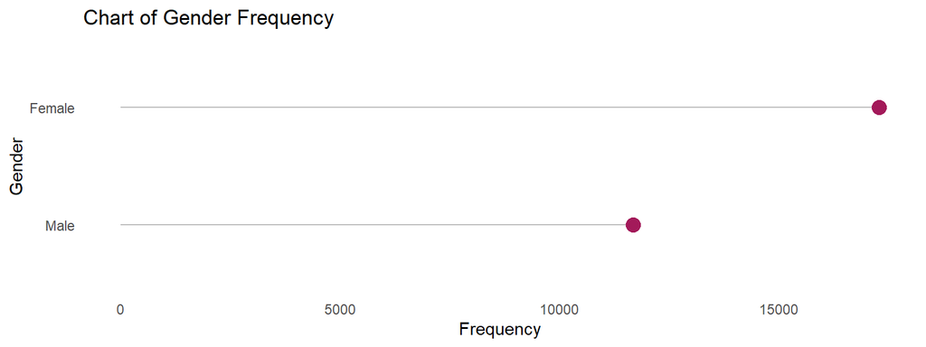

```r
gender_plot <- gender_count%>%
  ggplot(aes(x = reorder(Gender_recode,Freq), y = Freq))+
  geom_segment(aes( x = reorder(Gender_recode,Freq), y = 0 , xend = reorder(Gender_recode,Freq), yend = Freq), color = "gray")+
  geom_point( color = "#a31a5a", size = 4)+
  coord_flip()+
  theme_minimal()+
  labs(
    title = "Chart of Gender Frequency",
    x = "Gender",
    y = "Frequency"
  )+
  theme(panel.grid.major = element_blank(), panel.grid.minor = element_blank())


plot(gender_plot)
```

## 7.2 Frequency of Income categorical variable

```r
Income_freq <- table(can_path_merged$Income_recode)
Income_freq
```

```
##
##   10 000 $ - 24 999 $ 100 000 $ - 149 999 $ 150 000 $ - 199 999 $
##                  1568                  6357                  2916
##     200 000 $ or more   25 000 $ - 49 999 $   50 000 $ - 74 999 $
##                  2097                  4596                  5542
##   75 000 $ - 99 999 $    Less than 10 000 $
##                  5496                   385
```

### 7.2.1 Calculating percentage of each Income

```r
Income_prop <- prop.table(table(can_path_merged$Income_recode))*100
Income_prop
```

```
##
##   10 000 $ - 24 999 $ 100 000 $ - 149 999 $ 150 000 $ - 199 999 $
##              5.414926             21.953241             10.070104
##     200 000 $ or more   25 000 $ - 49 999 $   50 000 $ - 74 999 $
##              7.241772             15.871810             19.138723
##   75 000 $ - 99 999 $    Less than 10 000 $
##             18.979867              1.329558
```

### 7.2.2 Creating a frequency dataframe for Income

```r
Income_count <- can_path_merged %>%
  count(Income_recode) %>%
  rename( count = n) %>%
  arrange(desc(count))

Income_count
```

```
## # A tibble: 8 × 2
##   Income_recode         count
##   <fct>                 <int>
## 1 100 000 $ - 149 999 $  6357
## 2 50 000 $ - 74 999 $    5542
## 3 75 000 $ - 99 999 $    5496
## 4 25 000 $ - 49 999 $    4596
## 5 150 000 $ - 199 999 $  2916
## 6 200 000 $ or more      2097
## 7 10 000 $ - 24 999 $    1568
## 8 Less than 10 000 $      385
```

On the other hand, the lower-income brackets are comparatively less represented. The $10,000 - $24,999 range accounts for 1,568 individuals, while the Less than $10,000 bracket is the smallest group, with only 385 individuals.

### 7.2.3 Visualizing income variable using the Income_count

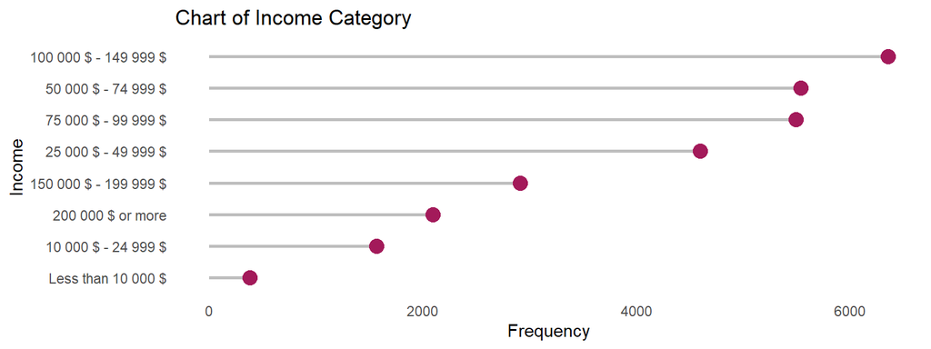

```r
Income_plot <- Income_count %>%
  ggplot(aes(x = reorder(Income_recode,count),  y = count))+
  geom_segment(aes( x = reorder(Income_recode,count), xend = reorder(Income_recode,count), y = 0,  yend = count),
               color = "gray", size = 1)+
  geom_point( color = "#a31a5a", size = 4)+
  coord_flip()+
  theme_minimal()+
  labs(
    title = "Chart of Income Category ",
    x = "Income",
    y = "Frequency"
  )+
  theme(panel.grid.major = element_blank(), panel.grid.minor = element_blank())
plot(Income_plot)
```

## 7.3 Frequency of *Gen health recode* categorical variable

```r
health_freq <- table(can_path_merged$Gen_health_recode)
health_freq
```

```
##
## Excellent      Fair      Good      Poor Very good
##      4944      2237      8871       542     12363
```

The majority of respondents rated their health as “Very good” (12,363) or “Good” (8,871), reflecting an overall positive perception of health. Smaller groups reported “Excellent” (4,944), “Fair” (2,237), or “Poor” (542) health, indicating fewer individuals with moderate or negative health perceptions.

### 7.3.1 Calculating percentage of each health category

```r
health_prop <- prop.table(health_freq)*100
health_prop
```

```
##
## Excellent      Fair      Good      Poor Very good
## 17.073592  7.725248 30.635080  1.871741 42.694340
```

Overall, respondents had a positive impression of their health, rating it as “Very good” (42.7%) or “Good” (30.6%). “Excellent” (17.1%), “Fair” (7.7%), and “Poor” (1.9%) were reported by smaller percentages.

### 7.3.2 Creating a frequency dataframe for health

```r
health_count <- can_path_merged %>%
  count(Gen_health_recode) %>%
  rename( count = n) %>%
  arrange(desc(count))

health_count
```

```
## # A tibble: 5 × 2
##   Gen_health_recode count
##   <fct>             <int>
## 1 Very good         12363
## 2 Good               8871
## 3 Excellent          4944
## 4 Fair               2237
## 5 Poor                542
```

### 7.3.3 Visualizing Health variable using the health_count

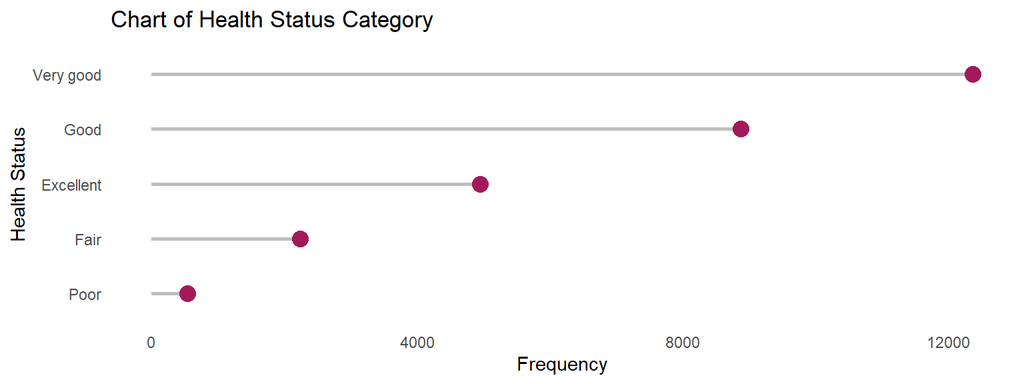

```r
health_plot <- health_count %>%
  ggplot(aes(x = reorder(Gen_health_recode,count),  y = count))+
  geom_segment(aes( x = reorder(Gen_health_recode,count), xend = reorder(Gen_health_recode,count), y = 0,  yend = count),
               color = "gray", size = 1)+
  geom_point( color = "#a31a5a", size = 4)+
  coord_flip()+
  theme_minimal()+
  labs(
    title = "Chart of Health Status Category ",
    x = "Health Status",
    y = "Frequency"
  )+
  theme(panel.grid.major = element_blank(), panel.grid.minor = element_blank())


plot(health_plot)
```

From the plot, it can be seen that most respondents had positive opinions on their health, with 12,363 rating it as “Very good” and 8,871 rating it as “Good.” 4,944 was rated as “Excellent.” There were smaller groups with 2,237 in “Fair” and 542 in “Poor,” which represented moderate or unfavorable health views. Most people consider their health to be satisfactory or even better overall.

## 7.4 Frequency of *Asthma_status_recode*

```r
asthma_freq <- table(can_path_merged$Asthma_status_recode)
asthma_freq
```

```
##
##             Ever had asthma            Never had asthma
##                        3666                       25064
## Presumed - Never had asthma
##                         227
```

### 7.4.1 Calculating percentage of each Asthma_status_recode category

```r
asthma_prop <- prop.table(asthma_freq)*100
asthma_prop
```

```
##
##             Ever had asthma            Never had asthma
##                   12.660151                   86.555928
## Presumed - Never had asthma
##                    0.783921
```

### 7.4.2 Creating a frequency dataframe for Asthma

```r
asthma_count <- can_path_merged %>%
  count(Asthma_status_recode) %>%
  rename(count = n) %>%
  mutate(percentage = (count / sum(count)) * 100) %>%
  arrange(desc(count))

asthma_count
```

```
## # A tibble: 3 × 3
##   Asthma_status_recode        count percentage
##   <fct>                       <int>      <dbl>
## 1 Never had asthma            25064     86.6
## 2 Ever had asthma              3666     12.7
## 3 Presumed - Never had asthma   227      0.784
```

### 7.4.3 Visualizing the Asthma_status_recode

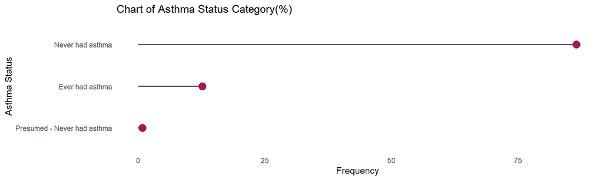

```r
asthma_plot <- asthma_count %>%
  ggplot(aes(x = reorder(Asthma_status_recode,percentage),  y = percentage))+
  geom_segment(aes(x = reorder(Asthma_status_recode,percentage),  yend = percentage, xend = reorder(Asthma_status_recode,percentage), y = 0))+
  geom_point(color = "#a31a5a", size = 4)+
  coord_flip()+
  theme_minimal()+
  labs(
    title = "Chart of Asthma Status Category(%) ",
    x = "Asthma Status",
    y = "Frequency"
  )+
  theme(panel.grid.major = element_blank(), panel.grid.minor = element_blank())


plot(asthma_plot)
```

## 7.5 Frequency of *PA Total Short cat* categorical variable

```r
PA_freq <- table(can_path_merged$PA_total_short_cat)
PA_freq
```

```
##
##     High Activity      Low Activity Moderate Activity
##              9322              6894             12741
```

According to the the frequency table,the largest group of 12,741 people engage in moderate activity. Next in line are 9,322 people who report high activity and 6,894 people who report low activity. With fewer falling into the low-activity category, this suggests that the majority of respondents maintain at least moderate levels of physical activity.

### 7.5.1 Calculating percentage of each Total Physical Activity Short category

```r
PA_prop <- prop.table(PA_freq)*100
PA_prop
```

```
##
##     High Activity      Low Activity Moderate Activity
##          32.19256          23.80771          43.99972
```

### 7.5.2 Creating a frequency dataframe for Total Physical Activity Short

```r
PA_count <- can_path_merged %>%
  count(PA_total_short_cat) %>%
  rename( count = n) %>%
  arrange(desc(count))

PA_count
```

```
## # A tibble: 3 × 2
##   PA_total_short_cat count
##   <fct>              <int>
## 1 Moderate Activity  12741
## 2 High Activity       9322
## 3 Low Activity        6894
```

According to the the frequency table,the largest group of 12,741 people engage in moderate activity. Next in line are 9,322 people who report high activity and 6,894 people who report low activity. With fewer falling into the low-activity category, this suggests that the majority of respondents maintain at least moderate levels of physical activity.

## 7.5.3 Visualizing Total Physical Activity Short variable

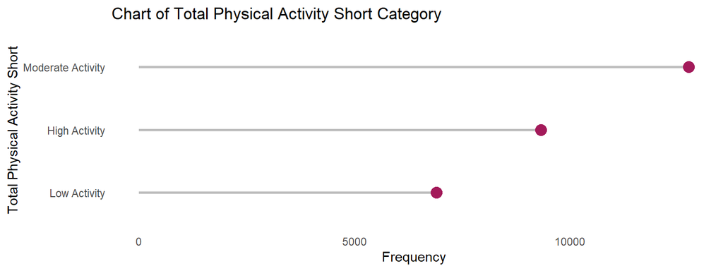

```r
PA_plot <- PA_count %>%
  ggplot(aes(x = reorder(PA_total_short_cat,count),  y = count))+
  geom_segment(aes( x = reorder(PA_total_short_cat,count), xend = reorder(PA_total_short_cat,count), y = 0,  yend = count),
               color = "gray", size = 1)+
  geom_point( color = "#a31a5a", size = 4)+
  coord_flip()+
  theme_minimal()+
  labs(
    title = "Chart of Total Physical Activity Short Category ",
    x = "Total Physical Activity Short",
    y = "Frequency"
  )+
  theme(panel.grid.major = element_blank(), panel.grid.minor = element_blank())


plot(PA_plot)
```

# **8 Descriptive Analysis of Numerical variables**

## 8.1 summary of Total Vegetable consumed variable

```r
summary(can_path_merged$Veg_qty)
```

```
##    Min. 1st Qu.  Median    Mean 3rd Qu.    Max.
##   0.000   2.000   2.000   2.661   3.000  35.000
```

The vegetable consumption for the respondents varies from 0 to 35 units, with 50% consuming 2 units or less. The average is 2.661 units, slightly affected by high outliers. Most of the respondents consumed 2–3 units, as 75% consumed 3 or fewer. A maximum of 35 units indicates a huge variability among the respondents.

### 8.1.1. Histogram of vegetable quantity

```r
veg_hist <- ggplot(can_path_merged, aes(x = Veg_qty))+
  geom_histogram(binwidth = 1)
  labs(
    title = "Histrogram of total vegetable consumed  ",
    x = "Total veg consumed",
    y = "Frequency"
  )+
  theme_minimal()+
  theme(panel.grid.major = element_blank(), panel.grid.minor = element_blank())
```

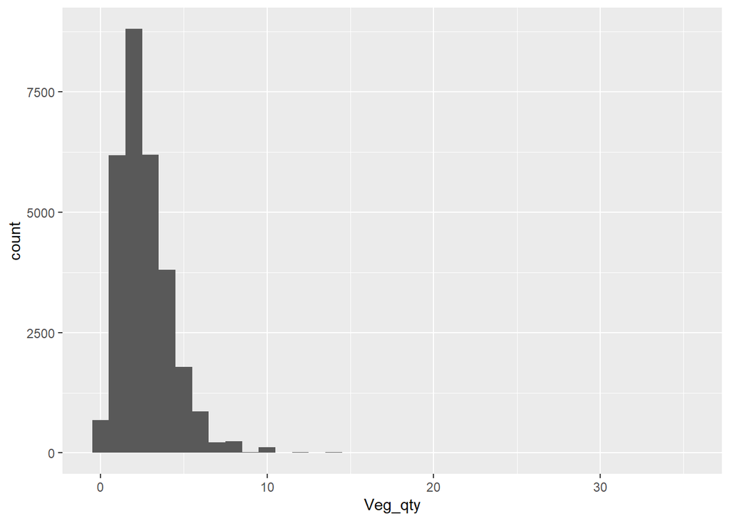

```r
plot(veg_hist)
```

The histogram above reflects a right-skewed distribution for vegetable consumption, with a majority of respondents consuming 0-5 units, with a peak of 2 units. Very few consume more than 10 units. ### 8.1.2 Boxplot of vegetable quantity

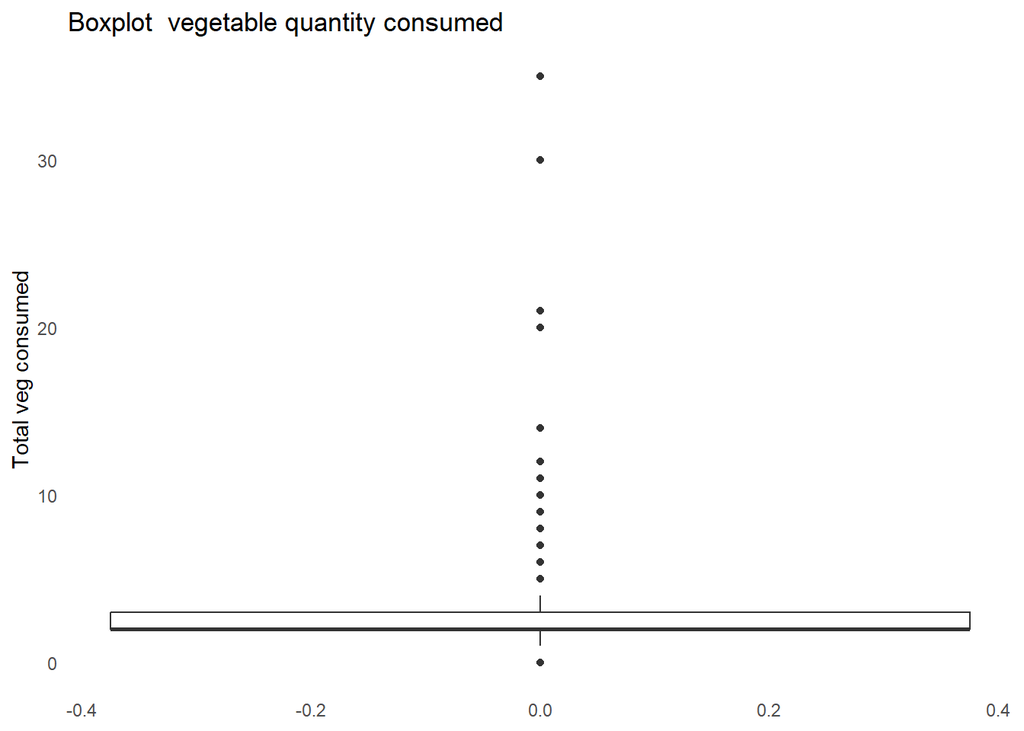

```r
veg_boxplot <- ggplot(can_path_merged, aes(x = Veg_qty))+
  geom_boxplot()+
  labs(
    title = "Boxplot  vegetable quantity consumed  ",
    x = "Total veg consumed"
  )+
  theme_minimal()+
  theme(panel.grid.major = element_blank(), panel.grid.minor = element_blank())+
  coord_flip()


plot(veg_boxplot)
```

The boxplot above indicates a low consumption rate for the majority and much variation with outliears extending from 5 to 35.

## 8.2 summary of Total Fruits consumed

```r
summary(can_path_merged$Fruits_qty)
```

```
##    Min. 1st Qu.  Median    Mean 3rd Qu.    Max.
##   0.000   1.000   2.000   2.126   3.000  21.000
```

there are respondents who recorded not having any fruit, about 25% consume below 1 fruit per day and 75% consume below 3 fruits. The maximum fruits consumed among the respondents is 21.

### 8.2.1 Histogram of fruits quantity

```r
fruits_hist <- ggplot(can_path_merged, aes(x = Fruits_qty))+
  geom_histogram(binwidth = 1)
  labs(
    title = "Histrogram of total fruits consumed  ",
    x = "Total fruits consumed",
    y = "Frequency"
  )+
  theme_minimal()+
  theme(panel.grid.major = element_blank(), panel.grid.minor = element_blank())
```

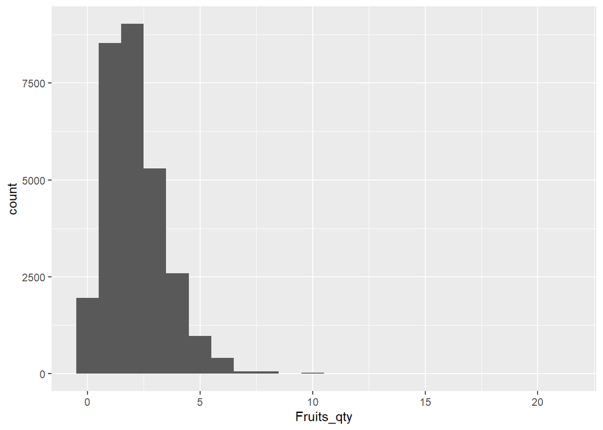

```r
plot(fruits_hist)
```

The histogram above represents fruits consumption among respondents. Majority consumed between 0 to about 4 fruits making the graph positively skewed with extreme values a bove 10.

### 8.2.2 Boxplot of fruits quantity

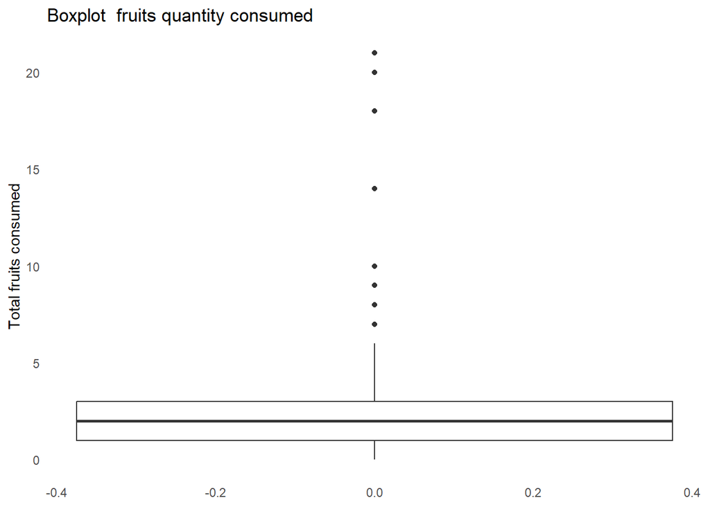

```r
fruit_boxplot <- ggplot(can_path_merged, aes(x = Fruits_qty))+
  geom_boxplot()+
  labs(
    title = "Boxplot  fruits quantity consumed  ",
    x = "Total fruits consumed"
  )+
  theme_minimal()+
  theme(panel.grid.major = element_blank(), panel.grid.minor = element_blank())+
  coord_flip()


plot(fruit_boxplot)
```

The majority of respondents consumed 1–3 units of fruits, while a small number consumed significantly higher amounts, creating noticeable outliers. The overall variation in fruit consumption is minimal for most respondents.

## 8.3 summary of Total Fruits and Vegetables consumed

```r
summary(can_path_merged$Tot_fruit_veg)
```

```
##    Min. 1st Qu.  Median    Mean 3rd Qu.    Max.
##   0.000   3.000   4.000   4.787   6.000  55.000
```

Total intake of fruits and vegetables has varied between 0 and 55 units. Most respondents consumed between 3 and 6 units; the median was 4, the mean 4.787, this last being influenced by outliers. Whereas the 75 percent consumed ≤ 6 units, the maximum of 55 reflects the consumption, very rarely, of a very high number.

### 8.3.1 Histogram of fruits and vegetable quantity

```r
fruits_veg_hist <- ggplot(can_path_merged, aes(x = Tot_fruit_veg))+
  geom_histogram(binwidth = 1)
  labs(
    title = "Histrogram of total fruits adn vegtable consumed  ",
    x = "Total fruits and vegetable consumed",
    y = "Frequency"
  )+
  theme_minimal()+
  theme(panel.grid.major = element_blank(), panel.grid.minor = element_blank())
```

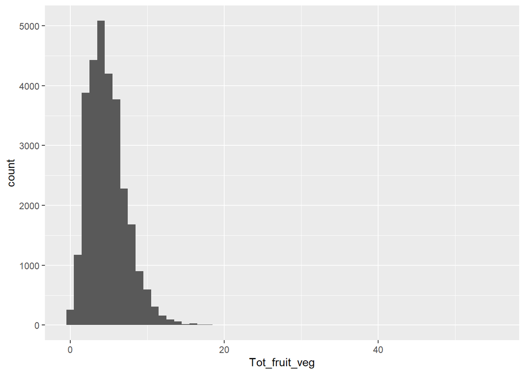

```r
plot(fruits_veg_hist)
```

The histogram of total fruits and vegetable is right-skewed with most of the respondents consume between 3-6 units of fruits and vegetables, while few outliers consume higher totals, thus creating a long tail.

### 8.3.2 Boxplot of fruits and vegetable quantity

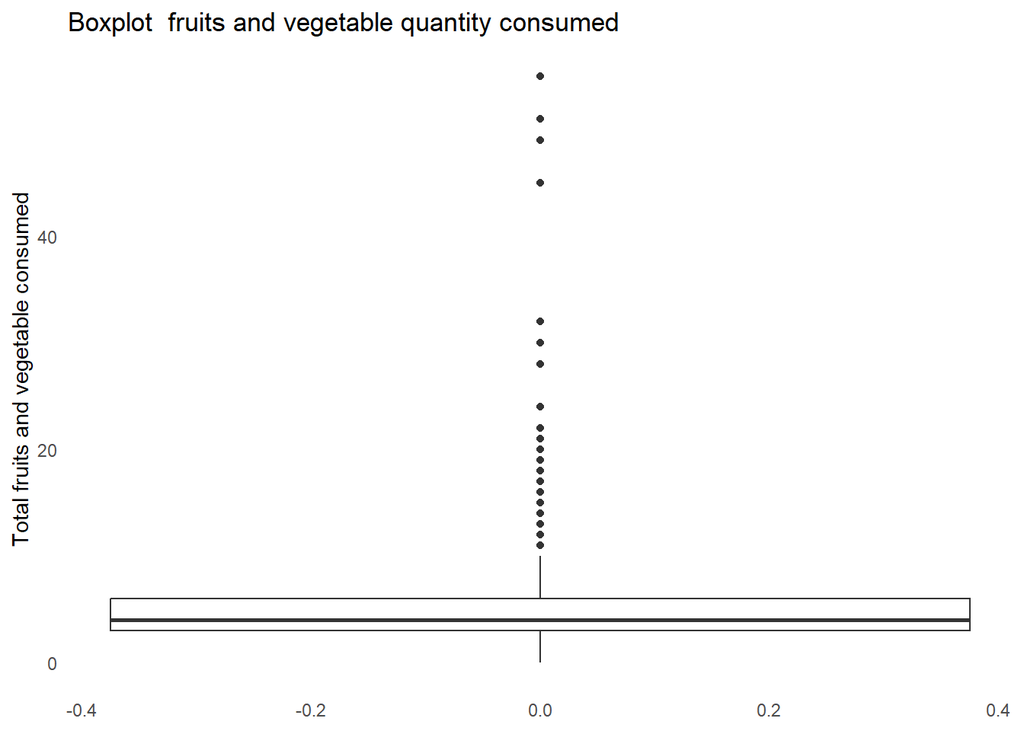

```r
fruit_veg_boxplot <- ggplot(can_path_merged, aes(x = Tot_fruit_veg))+
  geom_boxplot()+
  labs(
    title = "Boxplot  fruits and vegetable quantity consumed  ",
    x = "Total fruits and vegetable consumed"
  )+
  theme_minimal()+
  theme(panel.grid.major = element_blank(), panel.grid.minor = element_blank())+
  coord_flip()


plot(fruit_veg_boxplot)
```

The boxplot shows that the majority of respondents consumed between 3-6 units of fruits and vegetables, the median was 4. The whiskers are small in length, indicating small variation in typical consumption. There were several outliers, up to 55 units, reflecting very high consumption by a few respondents

## 8.4 summary of Total Physical activity short

```r
summary(can_path_merged$PA_total_short)
```

```
##    Min. 1st Qu.  Median    Mean 3rd Qu.    Max.
##       0     678    1830    2603    3786   19278
```

### 8.4.1 Histogram of Total Physical activity short

```r
PA_hist <- ggplot(can_path_merged, aes(x = PA_total_short))+
  geom_histogram(binwidth = 100)
  labs(
    title = "Histrogram of Total Physical activity short   ",
    x = "Total Physical activity short",
    y = "Frequency"
  )+
  theme_minimal()+
  theme(panel.grid.major = element_blank(), panel.grid.minor = element_blank())
```

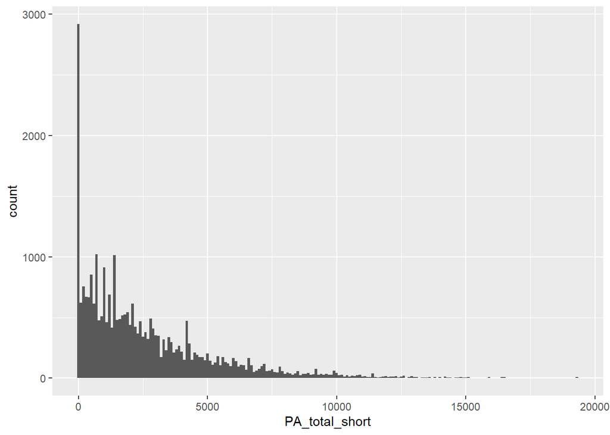

```r
plot(PA_hist)
```

### 8.4.2 Boxplot of Total Physical activity short

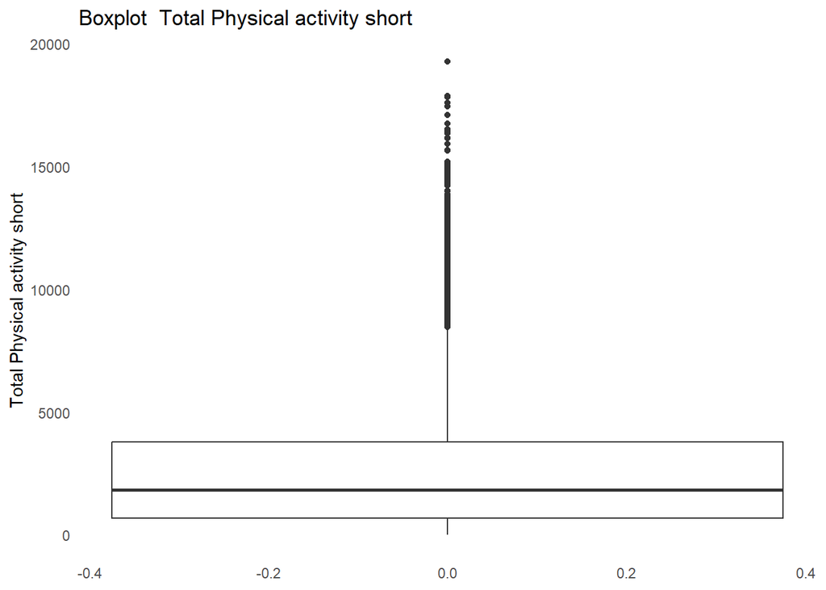

```r
PA_boxplot <- ggplot(can_path_merged, aes(x = PA_total_short))+
  geom_boxplot()+
  labs(
    title = "Boxplot  Total Physical activity short",
    x = "Total Physical activity short "
  )+
  theme_minimal()+
  theme(panel.grid.major = element_blank(), panel.grid.minor = element_blank())+
  coord_flip()


plot(PA_boxplot)
```

Numerous outliers, extending to around 20,0000, indicate exceptionally high activity levels for some respondents.Majority of respondents are concentrated below 5,000.

# **9 Numeric and Categorical variables**

## 9.1 Vegetable quantity

### 9.1.1 Analysis of Vegetable quantity by Gender

```r
gender_veg <- can_path_merged %>%
  group_by(Gender_recode) %>%
  summarise(mean_fruit_veg = mean(Veg_qty))

print(gender_veg)
```

```
## # A tibble: 2 × 2
##   Gender_recode mean_fruit_veg
##   <fct>                  <dbl>
## 1 Female                  2.92
## 2 Male                    2.28
```

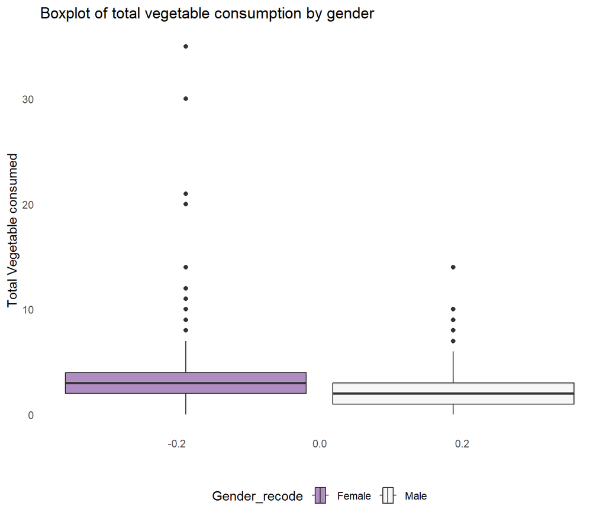

```r
ggplot(can_path_merged, aes(x = Veg_qty, fill = Gender_recode))+
  geom_boxplot()+
  scale_fill_brewer(palette = "PRGn")+
  coord_flip()+
  labs(title = "Boxplot of total vegetable consumption by gender",
       x = "Total Vegetable consumed",
       y= "")+
  theme_minimal()+
  theme(panel.grid.major = element_blank(), panel.grid.minor = element_blank(),
        legend.position = "bottom")
```

The boxplot indicates that females consume more vegetables on average than males. However, higher medians and more outliers can be observed in the female gender, reflecting greater variability in female consumption.

### 9.1.2 Analysis of Vegetable quantity by income category

```r
income_veg <- can_path_merged %>%
  group_by(Income_recode) %>%
  summarise(mean_veg = mean(Veg_qty)) %>%
  arrange(desc(mean_veg))

income_veg
```

```
## # A tibble: 8 × 2
##   Income_recode         mean_veg
##   <fct>                    <dbl>
## 1 200 000 $ or more         2.90
## 2 150 000 $ - 199 999 $     2.81
## 3 100 000 $ - 149 999 $     2.73
## 4 75 000 $ - 99 999 $       2.70
## 5 50 000 $ - 74 999 $       2.61
## 6 10 000 $ - 24 999 $       2.47
## 7 25 000 $ - 49 999 $       2.46
## 8 Less than 10 000 $        2.30
```

Vegetable consumption increases with increasing income, from the lowest average consumption of 2.30 units for those earning less than $10,000, to the highest average consumption of 2.90 units among those earning $200,000 or more.

### Boxplot of total vegetable consumpstion by income category

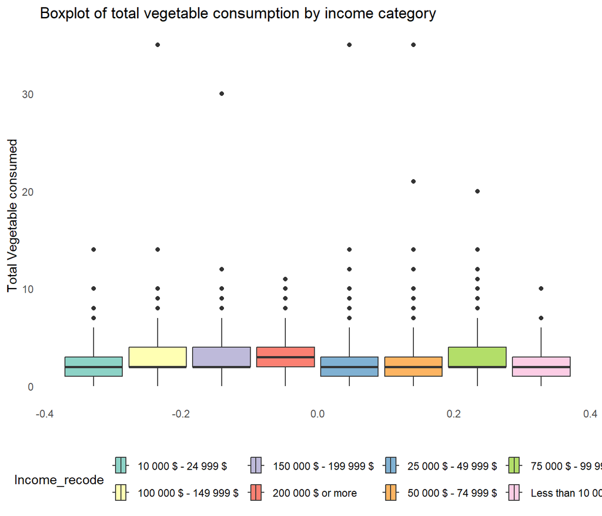

```r
ggplot(can_path_merged, aes(x = Veg_qty, fill = Income_recode))+
  geom_boxplot()+
  scale_fill_brewer(palette = "Set3")+
  coord_flip()+
  labs(title = "Boxplot of total vegetable consumption by income category",
       x = "Total Vegetable consumed",
       y= "")+
  theme_minimal()+
  theme(panel.grid.major = element_blank(), panel.grid.minor = element_blank(),
        legend.position = "bottom")
```

### 9.1.3 Analysis of Vegetable quantity by Health status

```r
health_veg <- can_path_merged %>%
  group_by(Gen_health_recode) %>%
  summarise(mean_veg = mean(Veg_qty)) %>%
  arrange(desc(mean_veg))

health_veg
```

```
## # A tibble: 5 × 2
##   Gen_health_recode mean_veg
##   <fct>                <dbl>
## 1 Excellent             3.01
## 2 Very good             2.72
## 3 Good                  2.48
## 4 Fair                  2.39
## 5 Poor                  2.21
```

From the frequency table, it can be observed that the mean of vegetable consumption is highest for those who perceive their health status as excellent and gradually decreases as self-rated health declines towards poor status.

### chart of total vegetable consumption by health status

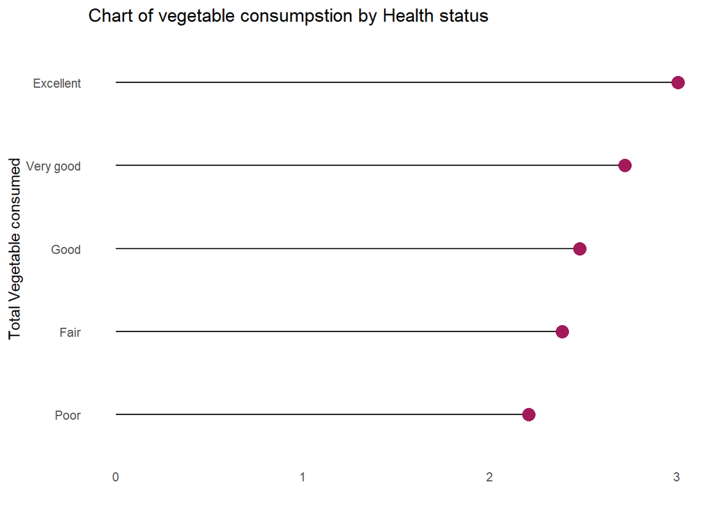

```r
ggplot(data = health_veg, aes(x = reorder(Gen_health_recode, mean_veg), y= mean_veg))+
  geom_segment(aes(x = reorder(Gen_health_recode, mean_veg), yend= mean_veg, xend =reorder(Gen_health_recode, mean_veg), y = 0 ))+
  geom_point( color = "#a31a5a", size = 4)+
  scale_fill_brewer( palette = "Set3")+
  labs(title = "Chart of vegetable consumpstion by Health status",
       x = "Total Vegetable consumed",
       y= "")+
  theme_minimal()+
  theme(panel.grid.major = element_blank(), panel.grid.minor = element_blank(),
        legend.position = "bottom")+
  coord_flip()
```

The chart above reveals that vegetable consumption is highest among individuals who rate their health as excellent and steadily declines as self-perceived health status worsens towards poor.

### Boxplot of total vegetable consumpstion by Health status

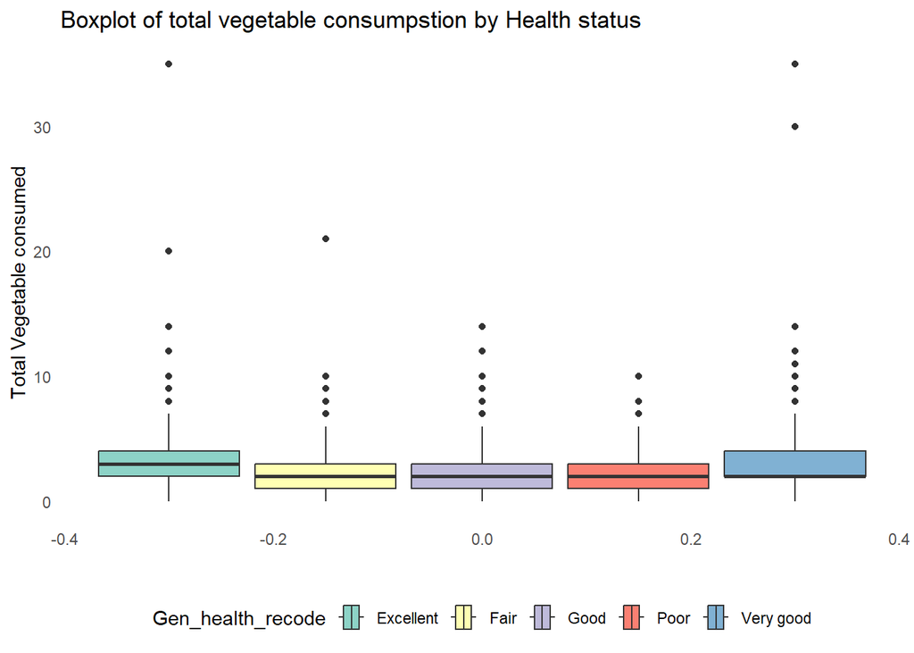

```r
ggplot(can_path_merged, aes(x = Veg_qty, fill = Gen_health_recode))+
  geom_boxplot()+
  scale_fill_brewer(palette = "Set3")+
  coord_flip()+
  labs(title = "Boxplot of total vegetable consumpstion by Health status",
       x = "Total Vegetable consumed",
       y= "")+
  theme_minimal()+
  theme(panel.grid.major = element_blank(), panel.grid.minor = element_blank(),
        legend.position = "bottom")
```

The boxplot shows higher vegetable consumption among respondents with excellent or very good health. Median consumption decreases as health ratings decline, with poor health associated with the lowest vegetable consumption and fewer outliers.

### 9.1.4 Analysis of Vegetable quantity by by Asthma status

```r
asthma_veg <- can_path_merged %>%
  group_by(Asthma_status_recode) %>%
  summarise(mean_veg = mean(Veg_qty)) %>%
  arrange(desc(mean_veg))

asthma_veg
```

```
## # A tibble: 3 × 2
##   Asthma_status_recode        mean_veg
##   <fct>                          <dbl>
## 1 Ever had asthma                 2.82
## 2 Presumed - Never had asthma     2.73
## 3 Never had asthma                2.64
```

The consumption of vegetables among those who ever had asthma is slightly higher compared to that of subjects who never had asthma, suggesting the possible relation of asthma history and dietary habits.

### Boxplot of total vegetable consumpstion by Asthma status

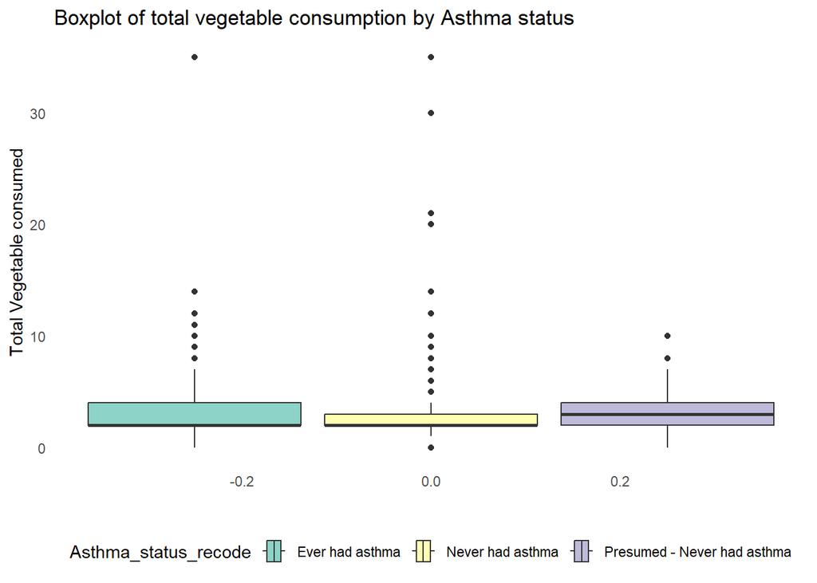

```r
ggplot(can_path_merged, aes(x = Veg_qty, fill = Asthma_status_recode))+
  geom_boxplot()+
  scale_fill_brewer(palette = "Set3")+
  coord_flip()+
  labs(title = "Boxplot of total vegetable consumption by Asthma status",
       x = "Total Vegetable consumed",
       y= "")+
  theme_minimal()+
  theme(panel.grid.major = element_blank(), panel.grid.minor = element_blank(),
        legend.position = "bottom")
```

Extreme outliers were seen in those who never had asthma compared to those who ever had asthma or presumed-never had asthma.

### 9.1.5 Analysis of Vegetable quantity by by Physical Activity short

```r
PA_veg <- can_path_merged %>%
  group_by(PA_total_short_cat) %>%
  summarise(mean_veg = mean(Veg_qty)) %>%
  arrange(desc(mean_veg))

PA_veg
```

```
## # A tibble: 3 × 2
##   PA_total_short_cat mean_veg
##   <fct>                 <dbl>
## 1 High Activity          2.86
## 2 Moderate Activity      2.70
## 3 Low Activity           2.33
```

Vegetable consumption is higher among those with high activity with a mean of 2.85 with decrease in mean observed as physical activity ratings decreases.

### chart of total vegetable consumption by Physical Activity

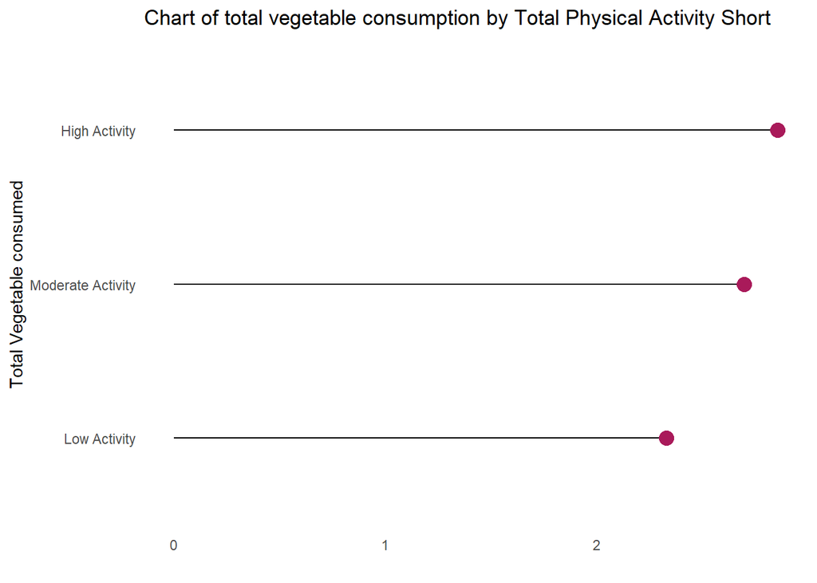

```r
ggplot(data = PA_veg, aes(x = reorder(PA_total_short_cat, mean_veg), y= mean_veg))+
  geom_segment(aes(x = reorder(PA_total_short_cat, mean_veg), yend= mean_veg, xend =reorder(PA_total_short_cat, mean_veg), y = 0 ))+
  geom_point( color = "#a91a5a", size = 4)+
  scale_fill_brewer( palette = "Set3")+
  labs(title = "Chart of total vegetable consumption by Total Physical Activity Short",
       x = "Total Vegetable consumed",
       y= "")+
  theme_minimal()+
  theme(panel.grid.major = element_blank(), panel.grid.minor = element_blank(),
        legend.position = "bottom")+
  coord_flip()
```

From the chart, it can be seen that those with high activity haas relatively longer bars and reduces steadily ad activity level reduces among respondents

### Boxplot of vegetable consumption by Physical Activity Short

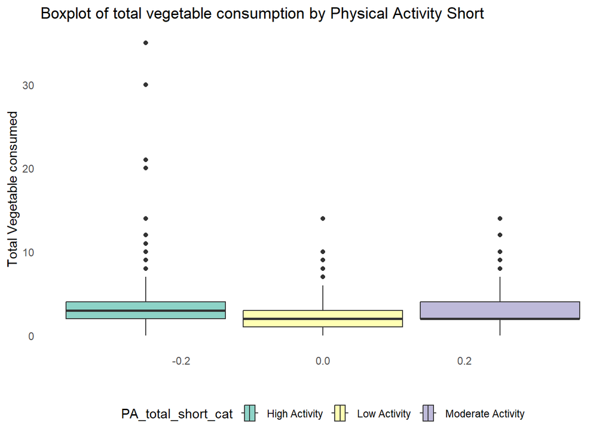

```r
ggplot(can_path_merged, aes(x = Veg_qty, fill = PA_total_short_cat))+
  geom_boxplot()+
  scale_fill_brewer(palette = "Set3")+
  coord_flip()+
  labs(title = "Boxplot of total vegetable consumption by Physical Activity Short",
       x = "Total Vegetable consumed",
       y= "")+
  theme_minimal()+
  theme(panel.grid.major = element_blank(), panel.grid.minor = element_blank(),
        legend.position = "bottom")
```

Outlier were seen in total vegetable quantity among those with high activity compared to those with low activity and moderate activity.

## 9.2 Fruit Quantity

### 9.2.1 Analysis of Fruit quantity by Gender

```r
gender_fruit <- can_path_merged %>%
  group_by(Gender_recode) %>%
  summarise(mean_fruit = mean(Fruits_qty))

gender_fruit
```

```
## # A tibble: 2 × 2
##   Gender_recode mean_fruit
##   <fct>              <dbl>
## 1 Female              2.29
## 2 Male                1.88
```

Mean fruit consumption is higher among females compared to males with means of 2.29 and 1.88 respectively.

### Boxplot of total fruit consumed by Gender

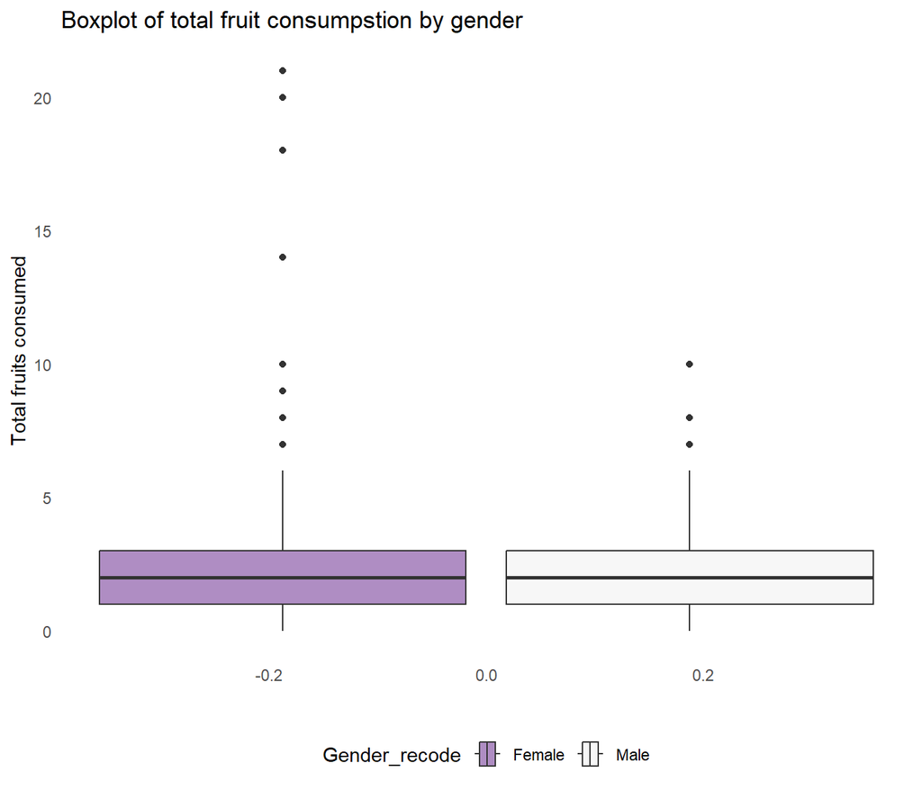

```r
ggplot(can_path_merged, aes(x = Fruits_qty, fill = Gender_recode))+
  geom_boxplot()+
  scale_fill_brewer(palette = "PRGn")+
  coord_flip()+
  labs(title = "Boxplot of total fruit consumpstion by gender",
       x = "Total fruits consumed",
       y= "")+
  theme_minimal()+
  theme(panel.grid.major = element_blank(), panel.grid.minor = element_blank(),
        legend.position = "bottom")
```

Outliers were observed among females which may influence their means compared to males.

### 9.2.2 Analysis of Fruit quantity by income category

```r
income_fruits <- can_path_merged %>%
  group_by(Income_recode) %>%
  summarise(mean_fruit = mean(Fruits_qty)) %>%
  arrange(desc(mean_fruit))

income_fruits
```

```
## # A tibble: 8 × 2
##   Income_recode         mean_fruit
##   <fct>                      <dbl>
## 1 200 000 $ or more           2.26
## 2 150 000 $ - 199 999 $       2.23
## 3 100 000 $ - 149 999 $       2.19
## 4 75 000 $ - 99 999 $         2.13
## 5 50 000 $ - 74 999 $         2.09
## 6 10 000 $ - 24 999 $         2.03
## 7 25 000 $ - 49 999 $         1.99
## 8 Less than 10 000 $          1.92
```

### Boxplot of total fruit consumption by income category

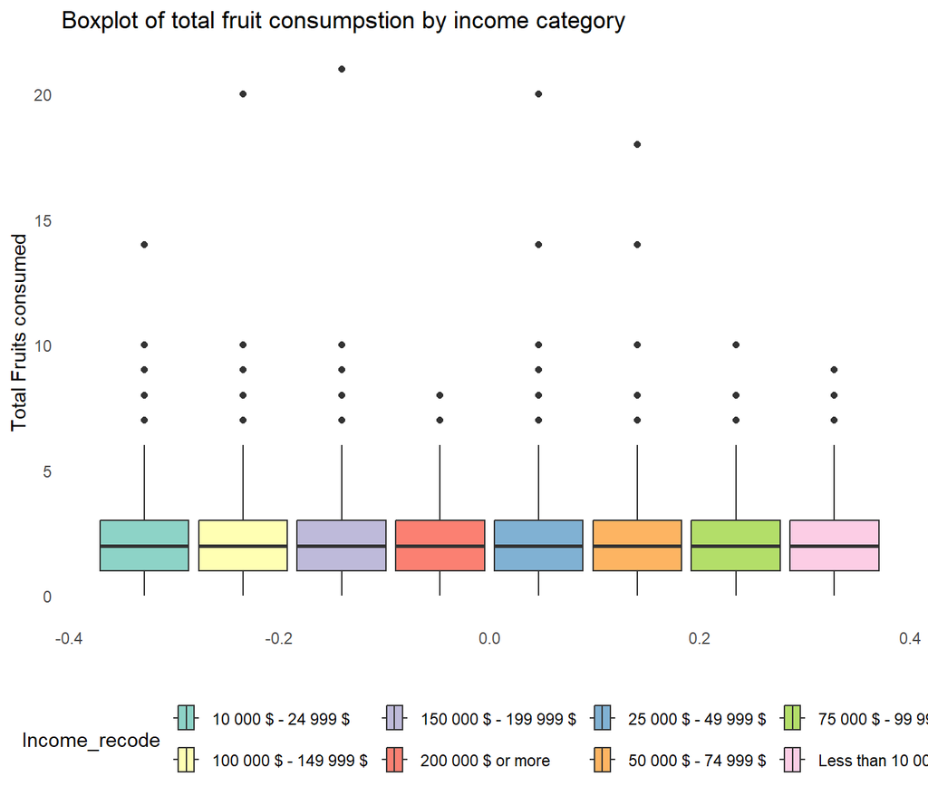

```r
ggplot(can_path_merged, aes(x = Fruits_qty, fill = Income_recode))+
  geom_boxplot()+
  scale_fill_brewer(palette = "Set3")+
  coord_flip()+
  labs(title = "Boxplot of total fruit consumpstion by income category",
       x = "Total Fruits consumed",
       y= "")+
  theme_minimal()+
  theme(panel.grid.major = element_blank(), panel.grid.minor = element_blank(),
        legend.position = "bottom")
```

### 9.2.3 Analysis of Fruit quantity by Health status

```r
health_fruits <- can_path_merged %>%
  group_by(Gen_health_recode) %>%
  summarise(mean_fruit = mean(Fruits_qty)) %>%
  arrange(desc(mean_fruit))

health_fruits
```

```
## # A tibble: 5 × 2
##   Gen_health_recode mean_fruit
##   <fct>                  <dbl>
## 1 Excellent               2.38
## 2 Very good               2.18
## 3 Good                    1.97
## 4 Fair                    1.96
## 5 Poor                    1.82
```

Mean fruit consumption is high among those with excellent health status followed with those who are classified as having health rating as very good and mean fruit consumption reduces as health status rating decreases.

### chart of total fruit consumption by health status

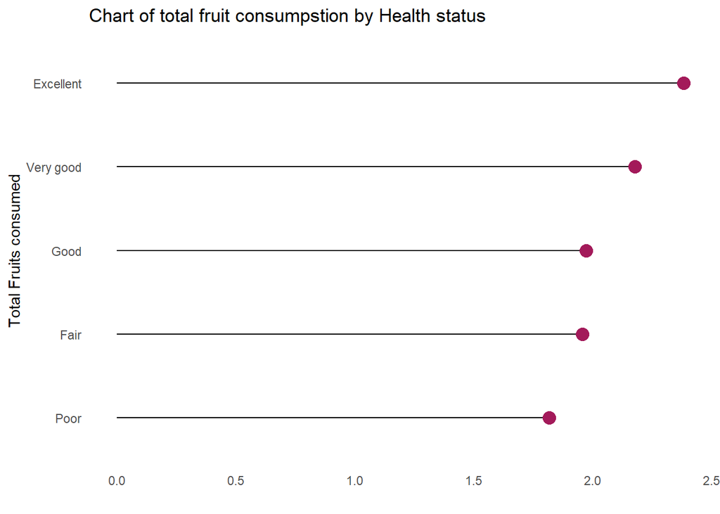

```r
ggplot(data = health_fruits, aes(x = reorder(Gen_health_recode, mean_fruit), y= mean_fruit))+
  geom_segment(aes(x = reorder(Gen_health_recode, mean_fruit), yend= mean_fruit, xend =reorder(Gen_health_recode, mean_fruit), y = 0 ))+
  geom_point( color = "#a31a5a", size = 4)+
  scale_fill_brewer( palette = "Set3")+
  labs(title = "Chart of total fruit consumpstion by Health status",
       x = "Total Fruits consumed",
       y= "")+
  theme_minimal()+
  theme(panel.grid.major = element_blank(), panel.grid.minor = element_blank(),
        legend.position = "bottom")+
  coord_flip()
```

### Boxplot of total fruit consumpstion by Health status

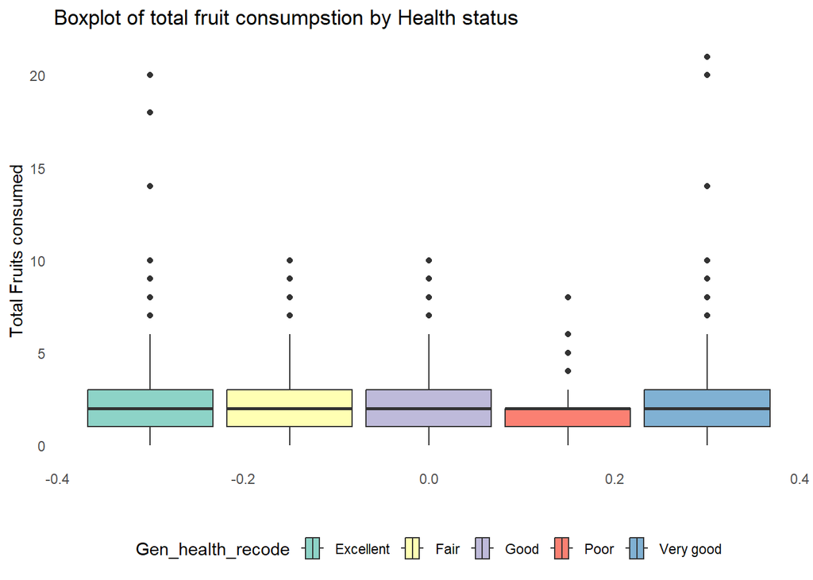

```r
ggplot(can_path_merged, aes(x = Fruits_qty, fill = Gen_health_recode))+
  geom_boxplot()+
  scale_fill_brewer(palette = "Set3")+
  coord_flip()+
  labs(title = "Boxplot of total fruit consumpstion by Health status",
       x = "Total Fruits consumed",
       y= "")+
  theme_minimal()+
  theme(panel.grid.major = element_blank(), panel.grid.minor = element_blank(),
        legend.position = "bottom")
```

### 9.2.4 Analysis of Fruit quantity by Asthma status

```r
asthma_fruit <- can_path_merged %>%
  group_by(Asthma_status_recode) %>%
  summarise(mean_fruit = mean(Fruits_qty)) %>%
  arrange(desc(mean_fruit))

asthma_fruit
```

```
## # A tibble: 3 × 2
##   Asthma_status_recode        mean_fruit
##   <fct>                            <dbl>
## 1 Presumed - Never had asthma       2.27
## 2 Ever had asthma                   2.20
## 3 Never had asthma                  2.11
```

From the table, it is observable that fruit consumption is highest among the subjects presumed never to have asthma, with 2.27 units, slightly less among those with asthma, 2.20, and the lowest among the non-asthmatics, 2.11.

### Boxplot of total fruit consumpstion by Asthma status

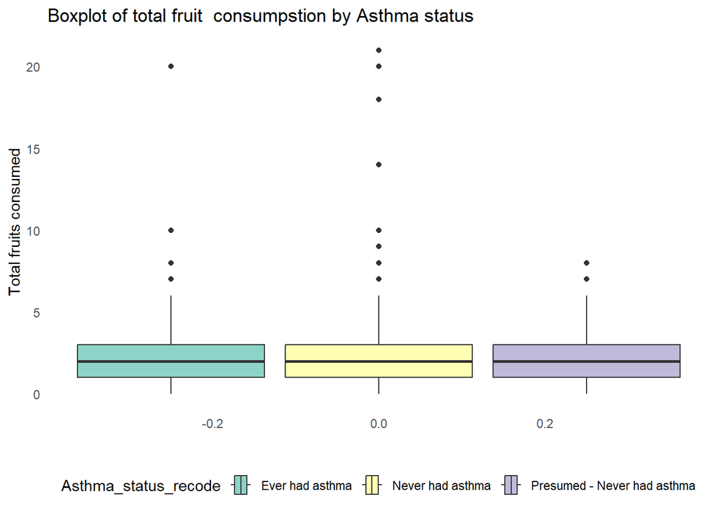

```r
ggplot(can_path_merged, aes(x = Fruits_qty, fill = Asthma_status_recode))+
  geom_boxplot()+
  scale_fill_brewer(palette = "Set3")+
  coord_flip()+
  labs(title = "Boxplot of total fruit  consumpstion by Asthma status",
       x = "Total fruits consumed",
       y= "")+
  theme_minimal()+
  theme(panel.grid.major = element_blank(), panel.grid.minor = element_blank(),
        legend.position = "bottom")
```

Fruit consumption varies a little according to asthma status. It is highest among respondents who probably never had asthma, and it is lowest among respondents who never had asthma. All three categories contain outliers with higher variation observed among those who have never had asthma.